# R and Python basics & time series datasets

# 1 Introduction

## 1.1 About

Examples in the notebook have equivalent **R** and **Python** tabs containing the code and its output. Choosing a language in one example switches all examples to that language. Both languages execute from top to bottom. Installation and classroom exercise snippets are intentionally not executed.

Quarto uses **knitr** for R and **reticulate** for Python in this document. Install the R packages listed below, using reticulate 1.41 or later. The loading chunk declares every Python dependency, including `openpyxl`, which pandas needs to read Excel files. If no Python environment is explicitly selected, reticulate creates a managed environment and installs those dependencies during the first render. If you select a particular Python environment with `RETICULATE_PYTHON`, install the listed Python packages in that environment yourself. Render with `quarto render 1_datasets.qmd`. See the [Quarto documentation](https://quarto.org/docs/computations/execution-options.html) for details about using both languages.

The Python examples use NumPy, pandas, seaborn, matplotlib, and statsmodels. Each language reads the same local World Bank file. Some later examples download data from online providers. Random draws differ between R and Python. The cryptocurrency examples use different providers, as explained in that section.

## 1.2 Structure of the crash course

1. **Introduction** to R basics & datasets + summary statistics
2. **Theory 1**: randomness, stationarity, unit roots, random walk
3. **Theory 2**: autocorrelation, ARMA models, predictive regressions
4. **Advanced models** (VAR, GARCH and neural networks) and prediction
5. **SOTA** (tabular foundation x time-series)

# 2 Packages

There are currently more than 23,000 packages on the [CRAN](https://cran.r-project.org/web/packages/).  
But many more exist on [github](https://github.com/). They are however not vetted/verified.

## 2.1 Installation

Just run the following chunk:

**R**

```r
options(timeout = 6000)
packages <- c("tidyverse", "openxlsx", "reticulate", "quantmod", "feasts",
              "tsibble", "fable", "crypto2", "ggsci")
missing <- setdiff(packages, rownames(installed.packages()))
if (length(missing)) install.packages(missing)
```

**Python**

```python
# Run once in a terminal with the Python interpreter used by reticulate:
# python -m pip install numpy pandas matplotlib seaborn statsmodels requests openpyxl yfinance
```

## 2.2 Loading

`library()` loads R packages; `import` loads Python modules.

**R**

```r
library(tidyverse)  # THE library for data science
library(openxlsx)   # A cool package to deal with Excel files/formats
library(quantmod)   # Package for financial data extraction
library(tsibble)    # TS with dataframes framework
library(fable)      # Package for time-series models & predictions
library(feasts)     # Package for time-series analysis
library(crypto2)    # Package to access crypto data
library(ggsci)      # For cool plot palettes & colors

# Declare optional dependencies too: pandas does not import openpyxl until Excel is read.
reticulate::py_require(c(
  "numpy", "pandas", "matplotlib", "seaborn", "statsmodels", "requests",
  "openpyxl>=3.1.5", "yfinance"
))
```

**Python**

```python
import io
import numpy as np
import pandas as pd
import openpyxl  # Excel reader used by pandas.
import matplotlib.pyplot as plt
import seaborn as sns
import requests
import yfinance as yf
from statsmodels.tsa.seasonal import seasonal_decompose

sns.set_theme(style="whitegrid")
pd.set_option("display.max_columns", 12)
```

# 3 Things to know with R and Python

## 3.1 Data structures, assigning & indexing

R commonly uses `<-` for assignment; Python uses `=`.

**R**

```r
a <- 6
a
```

```
[1] 6
```

**Python**

```python
a = 6
print(a)
```

```
6
```

Vectors of integers….

**R**

```r
1:12
```

```
 [1]  1  2  3  4  5  6  7  8  9 10 11 12
```

```r
12:1
```

```
 [1] 12 11 10  9  8  7  6  5  4  3  2  1
```

**Python**

```python
print(np.arange(1, 13))  # The upper bound is excluded.
```

```
[ 1  2  3  4  5  6  7  8  9 10 11 12]
```

```python
print(np.arange(12, 0, -1))
```

```
[12 11 10  9  8  7  6  5  4  3  2  1]
```

Sequences of equally-spaced numbers.

**R**

```r
seq(0, 1, by = 0.1)
```

```
 [1] 0.0 0.1 0.2 0.3 0.4 0.5 0.6 0.7 0.8 0.9 1.0
```

**Python**

```python
print(np.linspace(0, 1, 11))
```

```
[0.  0.1 0.2 0.3 0.4 0.5 0.6 0.7 0.8 0.9 1. ]
```

Custom vectors. This syntax is strange (compared to python/MATLAB), but super **IMPORTANT** in R.  
Essentially, you embed the elements with the simple **c()** function.

**R**

```r
c(2, 3, 5, 8, 13)
```

```
[1]  2  3  5  8 13
```

**Python**

```python
print(np.array([2, 3, 5, 8, 13]))
```

```
[ 2  3  5  8 13]
```

**Matrices**.

First method: stacking vectors (or smaller matrices).

**R**

```r
rbind(1:5, 2:6)
```

```
     [,1] [,2] [,3] [,4] [,5]
[1,]    1    2    3    4    5
[2,]    2    3    4    5    6
```

```r
cbind(1:5, 2:6)
```

```
     [,1] [,2]
[1,]    1    2
[2,]    2    3
[3,]    3    4
[4,]    4    5
[5,]    5    6
```

**Python**

```python
print(np.vstack([np.arange(1, 6), np.arange(2, 7)]))
```

```
[[1 2 3 4 5]
 [2 3 4 5 6]]
```

```python
print(np.column_stack([np.arange(1, 6), np.arange(2, 7)]))
```

```
[[1 2]
 [2 3]
 [3 4]
 [4 5]
 [5 6]]
```

Second method: filling with values.

**R**

```r
matrix(1:12, nrow = 3, byrow = T)
```

```
     [,1] [,2] [,3] [,4]
[1,]    1    2    3    4
[2,]    5    6    7    8
[3,]    9   10   11   12
```

**Python**

```python
print(np.arange(1, 13).reshape(3, 4))
```

```
[[ 1  2  3  4]
 [ 5  6  7  8]
 [ 9 10 11 12]]
```

**Indexing** starts at one in R and zero in Python. Python slices exclude their upper bound.

**R**

```r
M <- matrix(1:72, nrow = 6)
M
```

```
     [,1] [,2] [,3] [,4] [,5] [,6] [,7] [,8] [,9] [,10] [,11] [,12]
[1,]    1    7   13   19   25   31   37   43   49    55    61    67
[2,]    2    8   14   20   26   32   38   44   50    56    62    68
[3,]    3    9   15   21   27   33   39   45   51    57    63    69
[4,]    4   10   16   22   28   34   40   46   52    58    64    70
[5,]    5   11   17   23   29   35   41   47   53    59    65    71
[6,]    6   12   18   24   30   36   42   48   54    60    66    72
```

```r
M[2:5, 2:5] # rows first, then columns, ALWAYS!
```

```
     [,1] [,2] [,3] [,4]
[1,]    8   14   20   26
[2,]    9   15   21   27
[3,]   10   16   22   28
[4,]   11   17   23   29
```

**Python**

```python
# R fills matrices by column unless byrow = TRUE.
M = np.arange(1, 73).reshape(6, 12, order="F")
print(M)
```

```
[[ 1  7 13 19 25 31 37 43 49 55 61 67]
 [ 2  8 14 20 26 32 38 44 50 56 62 68]
 [ 3  9 15 21 27 33 39 45 51 57 63 69]
 [ 4 10 16 22 28 34 40 46 52 58 64 70]
 [ 5 11 17 23 29 35 41 47 53 59 65 71]
 [ 6 12 18 24 30 36 42 48 54 60 66 72]]
```

```python
# Python starts at zero and excludes the upper slice bound.
print(M[1:5, 1:5])  # The same rows and columns as R's M[2:5, 2:5].
```

```
[[ 8 14 20 26]
 [ 9 15 21 27]
 [10 16 22 28]
 [11 17 23 29]]
```

**Dataframes**: we can build them column-by-column. They are sometimes called “*tibbles*” in **R**.  
Most of the time, they are just imported from an external source (Excel spreadsheet).  
Below, we build one from scratch (this is often useful).

**R**

```r
n <- 12
data.frame(t = 1:n, x = rnorm(n), y = log(1:n))
```

| t | x | y |
| --- | --- | --- |
| 1 | -0.4135571 | 0.0000000 |
| 2 | -0.2741446 | 0.6931472 |
| 3 | -1.3924155 | 1.0986123 |
| 4 | -0.2583373 | 1.3862944 |
| 5 | -1.4378220 | 1.6094379 |
| 6 | 0.0966824 | 1.7917595 |
| 7 | 0.6419583 | 1.9459101 |
| 8 | -0.8854393 | 2.0794415 |
| 9 | 0.4925130 | 2.1972246 |
| 10 | -1.2162162 | 2.3025851 |
| 11 | 0.0991258 | 2.3978953 |
| 12 | 1.0309299 | 2.4849066 |

**Python**

```python
n = 12
rng = np.random.default_rng(123)
print(pd.DataFrame({
    "t": np.arange(1, n + 1),
    "x": rng.normal(size=n),
    "y": np.log(np.arange(1, n + 1)),
}))
```

```
     t         x         y
0    1 -0.989121  0.000000
1    2 -0.367787  0.693147
2    3  1.287925  1.098612
3    4  0.193974  1.386294
4    5  0.920231  1.609438
5    6  0.577104  1.791759
6    7 -0.636464  1.945910
7    8  0.541952  2.079442
8    9 -0.316595  2.197225
9   10 -0.322389  2.302585
10  11  0.097167  2.397895
11  12 -1.525930  2.484907
```

## 3.2 From type to type

Number $\rightarrow$ character.

**R**

```r
as.character(4)
```

```
[1] "4"
```

**Python**

```python
print(repr(str(4)))
```

```
'4'
```

Character $\rightarrow$ number.

**R**

```r
as.numeric("4.5")
```

```
[1] 4.5
```

**Python**

```python
print(float("4.5"))
```

```
4.5
```

Text $\rightarrow$ date. Don’t forget the [ISO-8601 standard](https://en.wikipedia.org/wiki/ISO_8601)…

**R**

```r
as.Date("13/02/2005", format = "%d/%m/%Y")
```

```
[1] "2005-02-13"
```

**Python**

```python
print(pd.to_datetime("13/02/2005", format="%d/%m/%Y").date())
```

```
2005-02-13
```

Dates again.

**R**

```r
as.Date("09/11/01", format = "%m/%d/%y")
```

```
[1] "2001-09-11"
```

**Python**

```python
print(pd.to_datetime("09/11/01", format="%m/%d/%y").date())
```

```
2001-09-11
```

Factors.

**R**

```r
as.factor(c("Large", "Medium", "Small", "Small", "Medium", "Large"))
```

```
[1] Large  Medium Small  Small  Medium Large
Levels: Large Medium Small
```

**Python**

```python
print(pd.Categorical(
    ["Large", "Medium", "Small", "Small", "Medium", "Large"],
    categories=["Large", "Medium", "Small"],
))
```

```
['Large', 'Medium', 'Small', 'Small', 'Medium', 'Large']
Categories (3, str): ['Large', 'Medium', 'Small']
```

## 3.3 The tidyverse and pandas

The [**tidyverse**](https://tidyverse.org/) is an ecosystem of packages that are incredibly useful in data science tasks.  
In particular:

- [**dplyr**](https://dplyr.tidyverse.org/index.html) and [**tidyr**](https://tidyr.tidyverse.org/) for wrangling
- [**ggplot**](https://ggplot2.tidyverse.org/) for plotting
- [**stringr**](https://stringr.tidyverse.org/) for string management
- [**lubridate**](https://lubridate.tidyverse.org/) for date management

Both tabs read the same local [World Development Indicators](https://datatopics.worldbank.org/world-development-indicators/) snapshot for 1960–2024. The file contains one row per economy or aggregate and year. Keep the `data` folder next to the notebook when you render it.

**R**

```r
wb_data <- read_csv("data/1_datasets_world_bank.csv", show_col_types = FALSE)
```

**Python**

```python
wb_data = pd.read_csv("data/1_datasets_world_bank.csv")
```

In pure time-series models, the variable(s) of interest are solely indexed by time $t$: $X_t$.  
**Panels** are somewhat richer, as they have two indices: time $t$ and individuals, often identified with $i$ or $n$.  
- For instance, in finance and economics, we have dynamic information for companies or countries. So data is written $X_{t,n}$.

Filtering observations ( = operate on **rows**).

**R**

```r
filter(wb_data[,1:8], year > 2012, country == "India")
```

| country | iso3c | year | pop | pop_growth | gdp_percap | gdp | R_D |
| --- | --- | --- | --- | --- | --- | --- | --- |
| India | IND | 2015 | 1328024498 | 1.1928556 | 1583.998 | 2.103588e+12 | 0.69310 |
| India | IND | 2014 | 1312277191 | 1.2612903 | 1553.884 | 2.039126e+12 | 0.70158 |
| India | IND | 2013 | 1295829511 | 1.3327043 | 1432.844 | 1.856722e+12 | 0.70642 |
| India | IND | 2016 | 1343944296 | 1.1916297 | 1707.509 | 2.294797e+12 | 0.66984 |
| India | IND | 2024 | 1450935791 | 0.8907065 | 2591.992 | 3.760813e+12 | NA |
| India | IND | 2017 | 1359657400 | 1.1623961 | 1950.105 | 2.651474e+12 | 0.66603 |
| India | IND | 2018 | 1374659064 | 1.0972991 | 1966.255 | 2.702930e+12 | 0.66001 |
| India | IND | 2023 | 1438069596 | 0.8832895 | 2434.448 | 3.500906e+12 | NA |
| India | IND | 2019 | 1389030312 | 1.0400140 | 2041.429 | 2.835606e+12 | 0.65942 |
| India | IND | 2020 | 1402617695 | 0.9734386 | 1907.043 | 2.674852e+12 | 0.64558 |
| India | IND | 2022 | 1425423212 | 0.7902005 | 2279.981 | 3.249938e+12 | NA |
| India | IND | 2021 | 1414203896 | 0.8226482 | 2239.614 | 3.167271e+12 | NA |

**Python**

```python
print(wb_data.loc[
    (wb_data["year"] > 2012) & (wb_data["country"] == "India")
].iloc[:, :8])
```

```
     country iso3c  year           pop  pop_growth   gdp_percap           gdp  \
7215   India   IND  2015  1.328024e+09    1.192856  1583.998159  2.103588e+12
7218   India   IND  2014  1.312277e+09    1.261290  1553.883961  2.039126e+12
7222   India   IND  2013  1.295830e+09    1.332704  1432.843975  1.856722e+12
7229   India   IND  2016  1.343944e+09    1.191630  1707.508929  2.294797e+12
7237   India   IND  2024  1.450936e+09    0.890707  2591.991661  3.760813e+12
7250   India   IND  2017  1.359657e+09    1.162396  1950.104683  2.651474e+12
7256   India   IND  2018  1.374659e+09    1.097299  1966.254552  2.702930e+12
7267   India   IND  2023  1.438070e+09    0.883290  2434.448263  3.500906e+12
7268   India   IND  2019  1.389030e+09    1.040014  2041.428637  2.835606e+12
7269   India   IND  2020  1.402618e+09    0.973439  1907.042516  2.674852e+12
7270   India   IND  2022  1.425423e+09    0.790201  2279.981457  3.249938e+12
7275   India   IND  2021  1.414204e+09    0.822648  2239.613844  3.167271e+12

          R_D
7215  0.69310
7218  0.70158
7222  0.70642
7229  0.66984
7237      NaN
7250  0.66603
7256  0.66001
7267      NaN
7268  0.65942
7269  0.64558
7270      NaN
7275      NaN
```

Ok so we see the ordering is a mess (look at the years)…  
Let’s sort that out.

**R**

```r
wb_data <- arrange(wb_data, country, year)
tail(wb_data, 5)
```

| country | iso3c | year | pop | pop_growth | gdp_percap | gdp | R_D | high_tech_exp | inflation | educ_spending | region | income |
| --- | --- | --- | --- | --- | --- | --- | --- | --- | --- | --- | --- | --- |
| Zimbabwe | ZWE | 2020 | 15526888 | 1.659353 | 2059.637 | 31979753645 | NA | 2.383868 | 557.20182 | NA | Sub-Saharan Africa | Lower middle income |
| Zimbabwe | ZWE | 2021 | 15797210 | 1.726011 | 2613.617 | 41287852524 | NA | 1.053740 | 98.54611 | NA | Sub-Saharan Africa | Lower middle income |
| Zimbabwe | ZWE | 2022 | 16069056 | 1.706209 | 2536.402 | 40757585309 | NA | 1.476931 | 104.70517 | NA | Sub-Saharan Africa | Lower middle income |
| Zimbabwe | ZWE | 2023 | 16340822 | 1.677096 | 2195.225 | 35871781303 | NA | 1.942188 | NA | 0.3847713 | Sub-Saharan Africa | Lower middle income |
| Zimbabwe | ZWE | 2024 | 16634373 | 1.780482 | 2496.155 | 41521975830 | NA | 2.798017 | NA | NA | Sub-Saharan Africa | Lower middle income |

**Python**

```python
wb_data = wb_data.sort_values(["country", "year"]).reset_index(drop=True)
print(wb_data.tail(5))
```

```
        country iso3c  year         pop  pop_growth   gdp_percap  ...  R_D  \
17285  Zimbabwe   ZWE  2020  15526888.0    1.659353  2059.637040  ...  NaN
17286  Zimbabwe   ZWE  2021  15797210.0    1.726011  2613.616741  ...  NaN
17287  Zimbabwe   ZWE  2022  16069056.0    1.706209  2536.401971  ...  NaN
17288  Zimbabwe   ZWE  2023  16340822.0    1.677096  2195.225020  ...  NaN
17289  Zimbabwe   ZWE  2024  16634373.0    1.780482  2496.155150  ...  NaN

       high_tech_exp   inflation  educ_spending              region  \
17285       2.383868  557.201817            NaN  Sub-Saharan Africa
17286       1.053740   98.546105            NaN  Sub-Saharan Africa
17287       1.476931  104.705171            NaN  Sub-Saharan Africa
17288       1.942188         NaN       0.384771  Sub-Saharan Africa
17289       2.798017         NaN            NaN  Sub-Saharan Africa

                    income
17285  Lower middle income
17286  Lower middle income
17287  Lower middle income
17288  Lower middle income
17289  Lower middle income

[5 rows x 13 columns]
```

For descending sorting:

**R**

```r
arrange(wb_data, desc(country), year) |> head(7)
```

| country | iso3c | year | pop | pop_growth | gdp_percap | gdp | R_D | high_tech_exp | inflation | educ_spending | region | income |
| --- | --- | --- | --- | --- | --- | --- | --- | --- | --- | --- | --- | --- |
| Zimbabwe | ZWE | 1960 | 3809389 | NA | 276.5609 | 1053528036 | NA | NA | NA | NA | Sub-Saharan Africa | Lower middle income |
| Zimbabwe | ZWE | 1961 | 3930401 | 3.127265 | 279.1589 | 1097206526 | NA | NA | NA | NA | Sub-Saharan Africa | Lower middle income |
| Zimbabwe | ZWE | 1962 | 4055959 | 3.144570 | 275.6863 | 1118172226 | NA | NA | NA | NA | Sub-Saharan Africa | Lower middle income |
| Zimbabwe | ZWE | 1963 | 4185877 | 3.152908 | 277.1471 | 1160103724 | NA | NA | NA | NA | Sub-Saharan Africa | Lower middle income |
| Zimbabwe | ZWE | 1964 | 4320006 | 3.154055 | 281.8884 | 1217759447 | NA | NA | NA | NA | Sub-Saharan Africa | Lower middle income |
| Zimbabwe | ZWE | 1965 | 4458462 | 3.154707 | 294.2955 | 1312105394 | NA | NA | NA | NA | Sub-Saharan Africa | Lower middle income |
| Zimbabwe | ZWE | 1966 | 4601217 | 3.151697 | 278.7097 | 1282403936 | NA | NA | NA | NA | Sub-Saharan Africa | Lower middle income |

**Python**

```python
print(wb_data.sort_values(["country", "year"], ascending=[False, True]).head(7))
```

```
        country iso3c  year        pop  pop_growth  gdp_percap  ...  R_D  \
17225  Zimbabwe   ZWE  1960  3809389.0         NaN  276.560896  ...  NaN
17226  Zimbabwe   ZWE  1961  3930401.0    3.127265  279.158927  ...  NaN
17227  Zimbabwe   ZWE  1962  4055959.0    3.144570  275.686274  ...  NaN
17228  Zimbabwe   ZWE  1963  4185877.0    3.152908  277.147113  ...  NaN
17229  Zimbabwe   ZWE  1964  4320006.0    3.154055  281.888369  ...  NaN
17230  Zimbabwe   ZWE  1965  4458462.0    3.154707  294.295520  ...  NaN
17231  Zimbabwe   ZWE  1966  4601217.0    3.151697  278.709728  ...  NaN

       high_tech_exp  inflation  educ_spending              region  \
17225            NaN        NaN            NaN  Sub-Saharan Africa
17226            NaN        NaN            NaN  Sub-Saharan Africa
17227            NaN        NaN            NaN  Sub-Saharan Africa
17228            NaN        NaN            NaN  Sub-Saharan Africa
17229            NaN        NaN            NaN  Sub-Saharan Africa
17230            NaN        NaN            NaN  Sub-Saharan Africa
17231            NaN        NaN            NaN  Sub-Saharan Africa

                    income
17225  Lower middle income
17226  Lower middle income
17227  Lower middle income
17228  Lower middle income
17229  Lower middle income
17230  Lower middle income
17231  Lower middle income

[7 rows x 13 columns]
```

Before we continue, we want to introduce a wonder of coding efficiency: **THE PIPE OPERATOR**.  
In fact, there are two of them and they are pretty similar: %>% and |>.  
The idea is to chain operations: the outcome of what comes before a pipe becomes the input of the pipe.  
We replicate the filter code above but via [**piping**](https://r4ds.had.co.nz/pipes.html).

**R**

```r
wb_data |> filter(country == "India", year > 2020)
```

| country | iso3c | year | pop | pop_growth | gdp_percap | gdp | R_D | high_tech_exp | inflation | educ_spending | region | income |
| --- | --- | --- | --- | --- | --- | --- | --- | --- | --- | --- | --- | --- |
| India | IND | 2021 | 1414203896 | 0.8226482 | 2239.614 | 3.167271e+12 | NA | 10.21256 | 5.131407 | 4.629500 | South Asia | Lower middle income |
| India | IND | 2022 | 1425423212 | 0.7902005 | 2279.981 | 3.249938e+12 | NA | 12.68228 | 6.699034 | 4.098658 | South Asia | Lower middle income |
| India | IND | 2023 | 1438069596 | 0.8832895 | 2434.448 | 3.500906e+12 | NA | 14.93435 | 5.649143 | NA | South Asia | Lower middle income |
| India | IND | 2024 | 1450935791 | 0.8907065 | 2591.992 | 3.760813e+12 | NA | 18.57239 | 4.953036 | NA | South Asia | Lower middle income |

**Python**

```python
# Parentheses let us chain pandas operations across several lines.
print(
    wb_data
    .query("country == 'India' and year > 2020")
)
```

```
     country iso3c  year           pop  pop_growth   gdp_percap  ...  R_D  \
7276   India   IND  2021  1.414204e+09    0.822648  2239.613844  ...  NaN
7277   India   IND  2022  1.425423e+09    0.790201  2279.981457  ...  NaN
7278   India   IND  2023  1.438070e+09    0.883290  2434.448263  ...  NaN
7279   India   IND  2024  1.450936e+09    0.890707  2591.991661  ...  NaN

      high_tech_exp  inflation  educ_spending      region               income
7276      10.212560   5.131407       4.629500  South Asia  Lower middle income
7277      12.682279   6.699034       4.098658  South Asia  Lower middle income
7278      14.934347   5.649143            NaN  South Asia  Lower middle income
7279      18.572395   4.953036            NaN  South Asia  Lower middle income

[4 rows x 13 columns]
```

And we check that, indeed, the data is now sorted. But now with **pipes**.  
The Python counterparts use pandas method chaining.

**Select** columns ( = operate on **columns**).

**R**

```r
wb_data |> select(country, year, pop_growth, gdp) |> tail()
```

| country | year | pop_growth | gdp |
| --- | --- | --- | --- |
| Zimbabwe | 2019 | 1.563533 | 33360632553 |
| Zimbabwe | 2020 | 1.659353 | 31979753645 |
| Zimbabwe | 2021 | 1.726011 | 41287852524 |
| Zimbabwe | 2022 | 1.706209 | 40757585309 |
| Zimbabwe | 2023 | 1.677096 | 35871781303 |
| Zimbabwe | 2024 | 1.780482 | 41521975830 |

**Python**

```python
print(wb_data.loc[:, ["country", "year", "pop_growth", "gdp"]].tail())
```

```
        country  year  pop_growth           gdp
17285  Zimbabwe  2020    1.659353  3.197975e+10
17286  Zimbabwe  2021    1.726011  4.128785e+10
17287  Zimbabwe  2022    1.706209  4.075759e+10
17288  Zimbabwe  2023    1.677096  3.587178e+10
17289  Zimbabwe  2024    1.780482  4.152198e+10
```

**Create** new columns with `mutate()` in R or `assign()` in pandas. Education spending is a percentage of GDP, so both examples divide by 100 to obtain spending in dollars.

**R**

```r
wb_data |>
  mutate(total_educ_spending = educ_spending * gdp / 100) |>
  select(country, year, total_educ_spending) |>
  filter(is.finite(total_educ_spending)) |>
  tail()
```

| country | year | total_educ_spending |
| --- | --- | --- |
| Zambia | 2023 | 1123456817 |
| Zimbabwe | 2010 | 186023976 |
| Zimbabwe | 2012 | 1039433080 |
| Zimbabwe | 2013 | 1145277409 |
| Zimbabwe | 2014 | 1197316632 |
| Zimbabwe | 2023 | 138024318 |

**Python**

```python
print(
    wb_data
    .assign(total_educ_spending=lambda d: d["educ_spending"] * d["gdp"] / 100)
    .loc[lambda d: np.isfinite(d["total_educ_spending"]),
         ["country", "year", "total_educ_spending"]]
    .tail()
)
```

```
        country  year  total_educ_spending
17275  Zimbabwe  2010         1.860240e+08
17277  Zimbabwe  2012         1.039433e+09
17278  Zimbabwe  2013         1.145277e+09
17279  Zimbabwe  2014         1.197317e+09
17288  Zimbabwe  2023         1.380243e+08
```

## 3.4 Tidy vs messy data

Tidy data seems simple:

1. Each variable is a column; each column is a variable.
2. Each observation is a row; each row is an observation.

But it’s not always easy to spot or understand at first.  
A counter-example can help:

**R**

```r
data.frame(Year = c(1970, 1990, 2010),
           France = c(52, 59, 65),
           Germany = c(61, 80, 82),
           UK = c(56, 57, 63))
```

| Year | France | Germany | UK |
| --- | --- | --- | --- |
| 1970 | 52 | 61 | 56 |
| 1990 | 59 | 80 | 57 |
| 2010 | 65 | 82 | 63 |

**Python**

```python
untidy = pd.DataFrame({
    "Year": [1970, 1990, 2010],
    "France": [52, 59, 65],
    "Germany": [61, 80, 82],
    "UK": [56, 57, 63],
})
print(untidy)
```

```
   Year  France  Germany  UK
0  1970      52       61  56
1  1990      59       80  57
2  2010      65       82  63
```

“France” is **not** a variable name. It’s a *value* for the *variable* “country”…  
Luckily, we have a tool to turn a dataset from messy to tidy: **pivot_longer**().  
All you need to do is:

1. Determine which columns (variables) to pivot;
2. Pick a name for the new column that will feature the column **names**;
3. Choose another name for the new column that will store the **values**.

An example below.

**R**

```r
data.frame(Year = c(1970, 1990, 2010),
           France = c(52, 59, 65),
           Germany = c(61, 80, 82),
           UK = c(56, 57, 63)) |>
  pivot_longer(-Year, names_to = "Country", values_to = "Population")
```

| Year | Country | Population |
| --- | --- | --- |
| 1970 | France | 52 |
| 1970 | Germany | 61 |
| 1970 | UK | 56 |
| 1990 | France | 59 |
| 1990 | Germany | 80 |
| 1990 | UK | 57 |
| 2010 | France | 65 |
| 2010 | Germany | 82 |
| 2010 | UK | 63 |

**Python**

```python
print(untidy.melt(id_vars="Year", var_name="Country", value_name="Population"))
```

```
   Year  Country  Population
0  1970   France          52
1  1990   France          59
2  2010   France          65
3  1970  Germany          61
4  1990  Germany          80
5  2010  Germany          82
6  1970       UK          56
7  1990       UK          57
8  2010       UK          63
```

Same information, but structured/presented differently.  
What happened? See below…

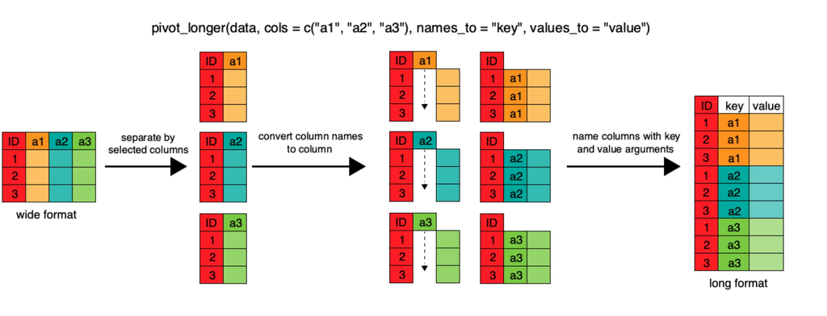

## 3.5 Pivot tables

These beasts can be incredibly useful. They require two steps:

1. Determine the **dimensions** (categorical columns) along which to perform the analysis: this is done with **group_by()**;
2. Define the **key metrics** to compute: this is done with **summarize()**.

**R**

```r
wb_data |>
  filter(year == 2023, region != "Aggregates") |>
  group_by(region) |>
  summarise(total_population = sum(pop))
```

| region | total_population |
| --- | --- |
| East Asia & Pacific | 2361056327 |
| Europe & Central Asia | 924805070 |
| Latin America & Caribbean | 654412725 |
| Middle East & North Africa | 508842198 |
| North America | 376868838 |
| South Asia | 1951539835 |
| Sub-Saharan Africa | 1240450857 |

**Python**

```python
print(
    wb_data.dropna(subset=["region"])
    .query("year == 2023 and region != 'Aggregates'")
    .groupby("region", dropna=False)["pop"]
    .agg(lambda s: s.sum(skipna=False))  # Matches R's sum without na.rm.
    .reset_index(name="total_population")
)
```

```
                       region  total_population
0         East Asia & Pacific      2.361056e+09
1       Europe & Central Asia      9.248051e+08
2   Latin America & Caribbean      6.544127e+08
3  Middle East & North Africa      5.088422e+08
4               North America      3.768688e+08
5                  South Asia      1.951540e+09
6          Sub-Saharan Africa      1.240451e+09
```

Below, “na.rm = T” means that NA data will be removed before applying the function.

**R**

```r
wb_data |>
  filter(region != "Aggregates") |>
  group_by(region, year) |>
  summarise(avg_gdp_percap = mean(gdp_percap, na.rm = T)) |>
  head(8)
```

| region | year | avg_gdp_percap |
| --- | --- | --- |
| East Asia & Pacific | 1960 | 523.1956 |
| East Asia & Pacific | 1961 | 536.6662 |
| East Asia & Pacific | 1962 | 548.0805 |
| East Asia & Pacific | 1963 | 595.7484 |
| East Asia & Pacific | 1964 | 638.6787 |
| East Asia & Pacific | 1965 | 787.4653 |
| East Asia & Pacific | 1966 | 841.1415 |
| East Asia & Pacific | 1967 | 797.1188 |

**Python**

```python
print(
    wb_data.dropna(subset=["region"]).query("region != 'Aggregates'")
    .groupby(["region", "year"], dropna=False)["gdp_percap"]
    .mean()  # pandas means skip missing values, like na.rm = TRUE.
    .reset_index(name="avg_gdp_percap")
    .head(8)
)
```

```
                region  year  avg_gdp_percap
0  East Asia & Pacific  1960      523.195626
1  East Asia & Pacific  1961      536.666156
2  East Asia & Pacific  1962      548.080515
3  East Asia & Pacific  1963      595.748432
4  East Asia & Pacific  1964      638.678708
5  East Asia & Pacific  1965      787.465328
6  East Asia & Pacific  1966      841.141535
7  East Asia & Pacific  1967      797.118839
```

A last example.

**R**

```r
wb_data |>
  group_by(income) |>
  summarise(avg_gdp_percap = mean(gdp_percap, na.rm = T))
```

| income | avg_gdp_percap |
| --- | --- |
| Aggregates | 5404.7941 |
| High income | 22930.3668 |
| Low income | 437.7856 |
| Lower middle income | 1164.4702 |
| Not classified | 3764.1398 |
| Upper middle income | 3478.4831 |
| NA | 4203.5584 |

**Python**

```python
print(
    wb_data.groupby("income", dropna=False)["gdp_percap"]
    .mean().reset_index(name="avg_gdp_percap")
)
```

```
                income  avg_gdp_percap
0           Aggregates     5404.794124
1          High income    22930.366835
2           Low income      437.785647
3  Lower middle income     1164.470156
4       Not classified     3764.139816
5  Upper middle income     3478.483063
6                  NaN     4203.558394
```

What is a low income country?

**R**

```r
wb_data |>
  filter(income == "Low income") |>
  select(country) |>
  distinct()
```

| country |
| --- |
| Afghanistan |
| Burkina Faso |
| Burundi |
| Central African Republic |
| Chad |
| Congo, Dem. Rep. |
| Eritrea |
| Ethiopia |
| Gambia, The |
| Guinea-Bissau |
| Korea, Dem. People’s Rep. |
| Liberia |
| Madagascar |
| Malawi |
| Mali |
| Mozambique |
| Niger |
| Rwanda |
| Sierra Leone |
| South Sudan |
| Sudan |
| Syrian Arab Republic |
| Togo |
| Uganda |
| Yemen, Rep. |

**Python**

```python
print(wb_data.loc[wb_data["income"] == "Low income", ["country"]].drop_duplicates())
```

```
                         country
0                    Afghanistan
2145                Burkina Faso
2210                     Burundi
2665    Central African Republic
2795                        Chad
3185            Congo, Dem. Rep.
4550                     Eritrea
4745                    Ethiopia
5590                 Gambia, The
6305               Guinea-Bissau
8125   Korea, Dem. People's Rep.
9035                     Liberia
9620                  Madagascar
9685                      Malawi
9880                        Mali
10920                 Mozambique
11505                      Niger
13195                     Rwanda
13715               Sierra Leone
14430                South Sudan
15080                      Sudan
15340       Syrian Arab Republic
15665                       Togo
16185                     Uganda
17095                Yemen, Rep.
```

## 3.6 Plots

[View the Financial Times visual vocabulary](https://github.com/Financial-Times/chart-doctor/blob/befb9cba21849432a4029d0cfdda938819ae733f/visual-vocabulary/poster.png)

Let’s illustrate this with a few examples. Below, we show information along 4 dimensions:

- **x-axis**
- **y-axis**
- **color**
- **shape** of point

**R**

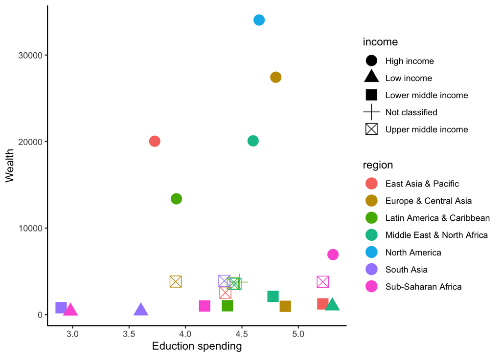

```r
wb_data |>
  filter(region != "Aggregates") |>
  group_by(region, income) |>
  summarise(avg_wealth = mean(gdp_percap,  na.rm = T),
            avg_educ = mean(educ_spending, na.rm = T)) |>
  na.omit() |>
  ggplot(aes(x = avg_educ, y = avg_wealth, color = region, shape = income)) +
  geom_point(size = 5) +
  xlab("Eduction spending") + ylab("Wealth") +
  theme_classic()
```

**Python**

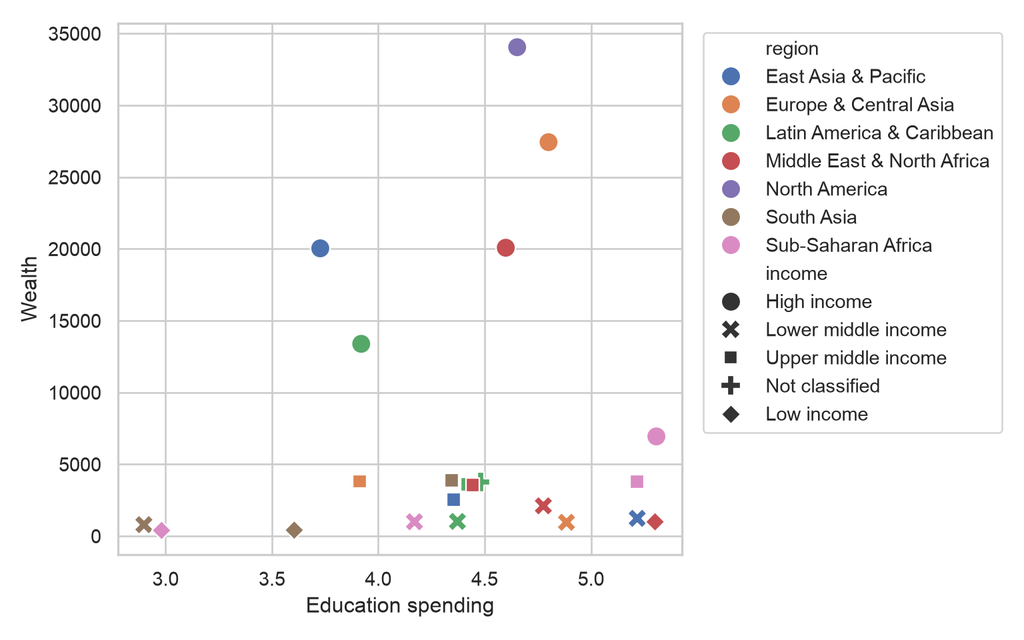

```python
plot_data = (
    wb_data.dropna(subset=["region"]).query("region != 'Aggregates'")
    .groupby(["region", "income"], dropna=False)
    .agg(avg_wealth=("gdp_percap", "mean"), avg_educ=("educ_spending", "mean"))
    .reset_index().dropna()
)
fig, ax = plt.subplots(figsize=(8, 5))
sns.scatterplot(data=plot_data, x="avg_educ", y="avg_wealth",
                hue="region", style="income", s=120, ax=ax)
ax.set(xlabel="Education spending", ylabel="Wealth")
ax.legend(bbox_to_anchor=(1.02, 1), loc="upper left")
fig.tight_layout()
plt.show()
```

Other potential dimensions include:

- **alpha** (transparency)
- **size** (for points)
- **fill** (the inside of shapes/rectangles)
- **linetype** (for lines)
- **linewidth** (for lines)

Look at the %in% operator below… much better than OR |

**R**

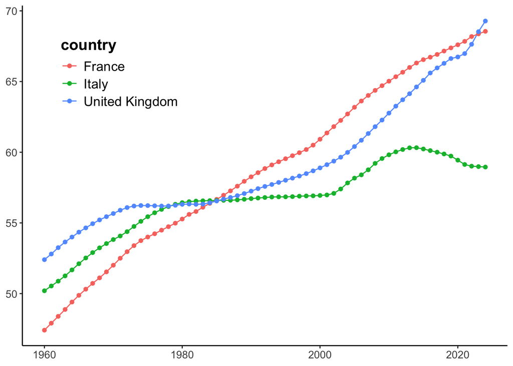

```r
wb_data |>
  filter(country %in% c("France", "Italy", "United Kingdom")) |>
  ggplot(aes(x = year, y = pop/10^6, color = country)) +
  geom_line() + geom_point() +
  theme_classic() +
  theme(axis.title = element_blank(),
        text = element_text(size = 13),
        legend.text = element_text(size = 13),
        legend.title = element_text(face = "bold", size = 15),
        legend.position = c(0.2,0.8))
```

**Python**

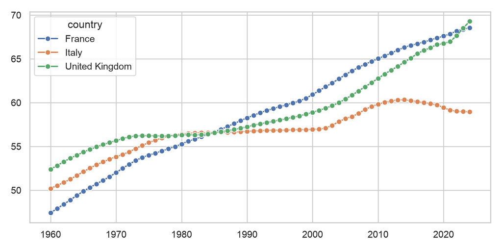

```python
plot_data = wb_data.loc[
    wb_data["country"].isin(["France", "Italy", "United Kingdom"])
].assign(pop_millions=lambda d: d["pop"] / 1e6)
fig, ax = plt.subplots(figsize=(8, 4))
sns.lineplot(data=plot_data, x="year", y="pop_millions", hue="country",
             marker="o", estimator=None, ax=ax)
ax.set(xlabel="", ylabel="")
fig.tight_layout()
plt.show()
```

A closer look at the syntax:

$$\underbrace{\text{ggplot}}_{\substack{\text{function} \\ \text{call}}}\left(\underbrace{\text{aes}(\text{x = } \overbrace{\text{year}}^{\substack{\text{column} \\ \text{name}}}, \ \text{y = } \overbrace{\text{population}}^{\substack{\text{column} \\ \text{name}}}, , \ \text{color = } \overbrace{\text{country}}^{\substack{\text{column} \\ \text{name}}}}_{\text{aesthetics}})\right) \ + \ \underbrace{\text{geom_line()}}_{\substack{\text{geometry}\\ \text{(graph type)}}}$$

Both elements the **aesthetics** and the **geom type** are crucial.  
Also, mind the “+” that separates the layers, it is **not a pipe**!

Another example, using a recycled pivot table.  
na.omit() removes rows with missing data.

**R**

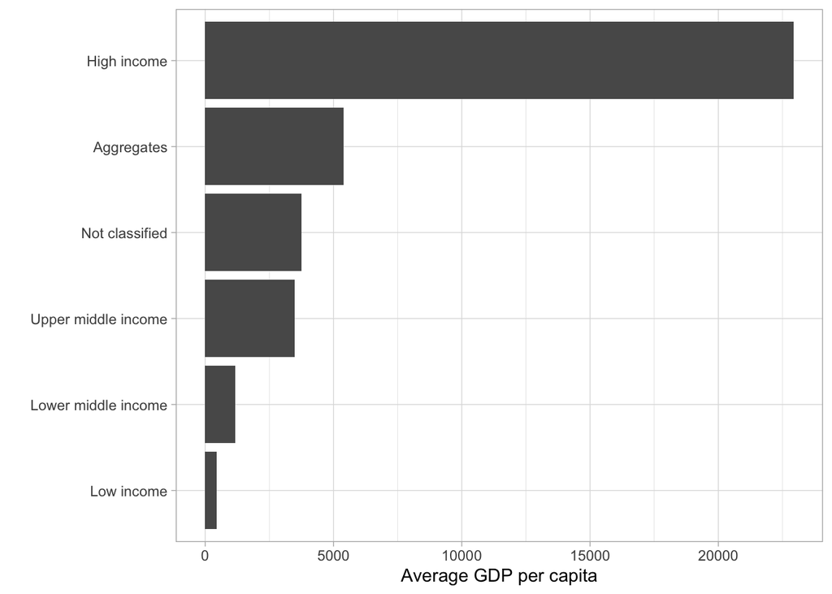

```r
wb_data |>
  group_by(income) |>
  summarise(avg_gdp_percap = mean(gdp_percap, na.rm = T)) |>
  na.omit() |>
  ggplot(aes(y = reorder(income, avg_gdp_percap), x = avg_gdp_percap)) +
  geom_col() +
  xlab("Average GDP per capita") + ylab("") +
  theme_light()
```

**Python**

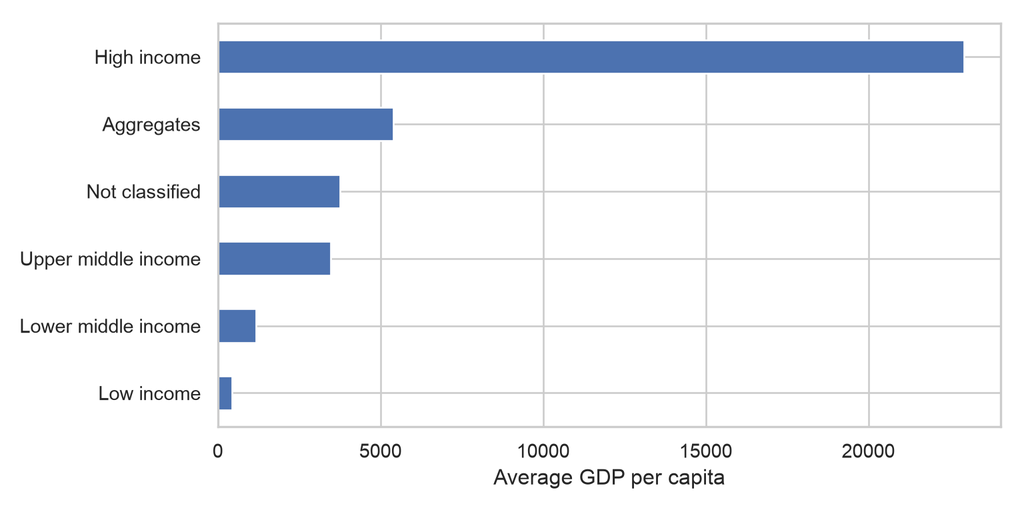

```python
plot_data = (
    wb_data.groupby("income")["gdp_percap"].mean().dropna().sort_values()
)
fig, ax = plt.subplots(figsize=(8, 4))
plot_data.plot.barh(ax=ax)
ax.set(xlabel="Average GDP per capita", ylabel="")
fig.tight_layout()
plt.show()
```

A last one for the road.

**R**

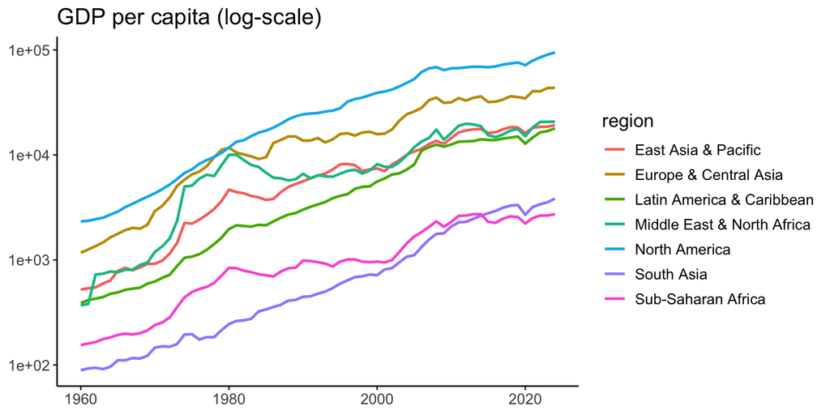

```r
wb_data |>
  filter(region != "Aggregates") |>
  group_by(region, year) |>
  summarise(avg_gdp_percap = mean(gdp_percap, na.rm = T)) |>
  ggplot(aes(x = year, y = avg_gdp_percap, color = region)) +
  geom_line(linewidth = 0.9) +
  scale_y_log10() +
  theme_classic() +
  theme(axis.title = element_blank(),
        text = element_text(size = 13)) +
  ggtitle("GDP per capita (log-scale)")
```

**Python**

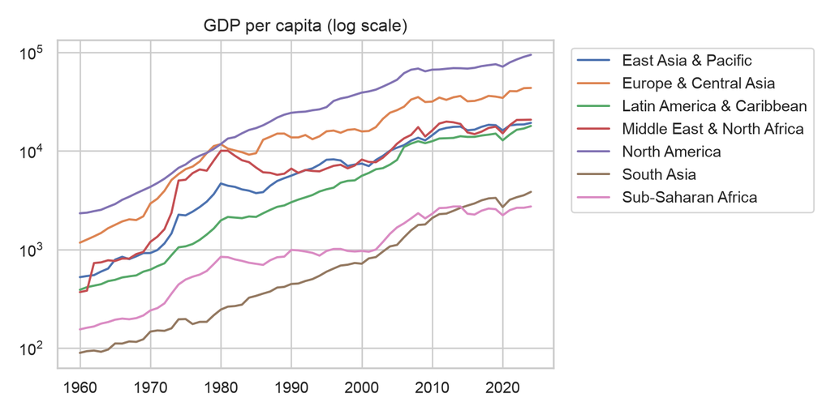

```python
plot_data = (
    wb_data.dropna(subset=["region"]).query("region != 'Aggregates'")
    .groupby(["region", "year"])["gdp_percap"].mean()
    .reset_index(name="avg_gdp_percap")
)
fig, ax = plt.subplots(figsize=(8, 4))
sns.lineplot(data=plot_data, x="year", y="avg_gdp_percap", hue="region", ax=ax)
ax.set(yscale="log", xlabel="", ylabel="", title="GDP per capita (log scale)")
ax.legend(bbox_to_anchor=(1.02, 1), loc="upper left")
fig.tight_layout()
plt.show()
```

# 4 Other datasets

## 4.1 Airline traffic

Let’s have a look at some data. Below, we dive into airline traffic, obtained from [Aéroport de Paris](https://www.parisaeroport.fr/en/group/finance/investor-relations/traffic).[^1]

Upon inspection, we need to open the third spreadsheet and focus on the first three columns:

- **date**
- **number of passengers for CDG**
- **number of passengers for ORY**

This file was manually edited to avoid errors (duplicated dates in the original sample.).

**R**

```r
url <- "https://github.com/shokru/coqueret.github.io/raw/refs/heads/master/files/misc/time_series/traffic-sheet.xlsx"
airline <- read.xlsx(url, sheet = 3, startRow = 2)
head(airline)
```

| X1 | Paris.-.Charles.de.Gaulle | Paris.-.Orly | Total | Paris.-.Charles.de.Gaulle | Paris.-.Orly | Total |
| --- | --- | --- | --- | --- | --- | --- |
| 36526 | 3223328 | 1935261 | 5158589 | 39489 | 19956 | 59445 |
| 36557 | 3289676 | 1942750 | 5232426 | 38386 | 19347 | 57733 |
| 36586 | 3891206 | 2204640 | 6095846 | 42049 | 21286 | 63335 |
| 36617 | 4221430 | 2266448 | 6487878 | 42931 | 20192 | 63123 |
| 36647 | 4217758 | 2203570 | 6421328 | 43909 | 20921 | 64830 |
| 36678 | 4279344 | 2190218 | 6469562 | 41966 | 19331 | 61297 |

**Python**

```python
url = "https://github.com/shokru/coqueret.github.io/raw/refs/heads/master/files/misc/time_series/traffic-sheet.xlsx"
response = requests.get(url, timeout=120)
response.raise_for_status()
# Python counts worksheets and header rows from zero.
airline = pd.read_excel(io.BytesIO(response.content), sheet_name=2, header=1, engine="openpyxl")
print(airline.head())
```

```
            Unnamed: 0  Paris\n-\nCharles de Gaulle  Paris\n-\nOrly  \
0  2000-01-01 00:00:00                    3223328.0       1935261.0
1  2000-02-01 00:00:00                    3289676.0       1942750.0
2  2000-03-01 00:00:00                    3891206.0       2204640.0
3  2000-04-01 00:00:00                    4221430.0       2266448.0
4  2000-05-01 00:00:00                    4217758.0       2203570.0

       Total  Paris\n-\nCharles de Gaulle.1  Paris\n-\nOrly.1  Total.1
0  5158589.0                        39489.0           19956.0  59445.0
1  5232426.0                        38386.0           19347.0  57733.0
2  6095846.0                        42049.0           21286.0  63335.0
3  6487878.0                        42931.0           20192.0  63123.0
4  6421328.0                        43909.0           20921.0  64830.0
```

Next, let do a bit of wrangling.

**R**

```r
air_data <- airline |> select(1:3)                  # Keep only the first 3 columns
colnames(air_data) <- c("date", "CDG", "ORY")       # Rename these columns
air_data <- air_data |>                             # Reformat the date
  mutate(date = as.Date(as.numeric(date), origin = "1899-12-30")) |>
  filter(is.finite(date), is.finite(CDG)) |>
  arrange(date)
```

**Python**

```python
air_data = airline.iloc[:, :3].copy()
air_data.columns = ["date", "CDG", "ORY"]
# openpyxl usually converts Excel dates to datetime objects already.
if pd.api.types.is_numeric_dtype(air_data["date"]):
    air_data["date"] = pd.to_datetime(
        air_data["date"], unit="D", origin="1899-12-30", errors="coerce",
    )
else:
    air_data["date"] = pd.to_datetime(air_data["date"], errors="coerce")
for column in ["CDG", "ORY"]:
    air_data[column] = pd.to_numeric(air_data[column], errors="coerce")
air_data = (
    air_data.loc[air_data["date"].notna() & np.isfinite(air_data["CDG"])]
    .sort_values("date")
)
```

To make the most of the `{fable}` [package](https://fable.tidyverts.org), we need to embed the dataframe into a **tsibble**, a kind of strange animal (data format) that the package really likes.

**R**

```r
air_data <- air_data |>
  mutate(date = yearmonth(date)) |>
  distinct(date, .keep_all = T) |>
  as_tsibble() |>
  fill_gaps()
```

**Python**

```python
# A monthly PeriodIndex plays the role of the tsibble index.
air_data["date"] = air_data["date"].dt.to_period("M")
air_data = air_data.drop_duplicates("date").set_index("date")
air_data = air_data.reindex(pd.period_range(
    air_data.index.min(), air_data.index.max(), freq="M", name="date",
))
print(air_data.head())
```

```
               CDG        ORY
date
2000-01  3223328.0  1935261.0
2000-02  3289676.0  1942750.0
2000-03  3891206.0  2204640.0
2000-04  4221430.0  2266448.0
2000-05  4217758.0  2203570.0
```

The Python example uses a monthly pandas index and reindexes it to insert missing months.

Let’s plot all of this!

**R**

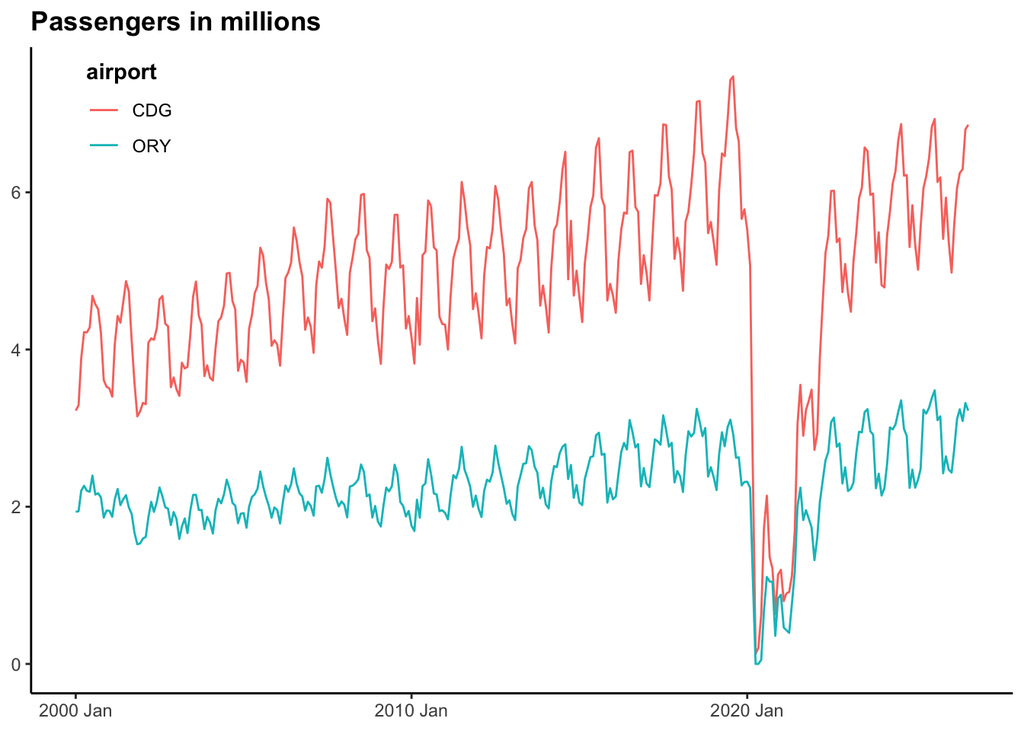

```r
air_data |>
  pivot_longer(-date, names_to = "airport", values_to = "passengers") |>
  ggplot(aes(x = date, y = passengers/10^6, color = airport)) + geom_line() +
  theme_classic() + ggtitle("Passengers in millions") +
  theme(axis.title = element_blank(),
        title = element_text(face = "bold"),
        legend.position = c(0.1,0.9))
```

**Python**

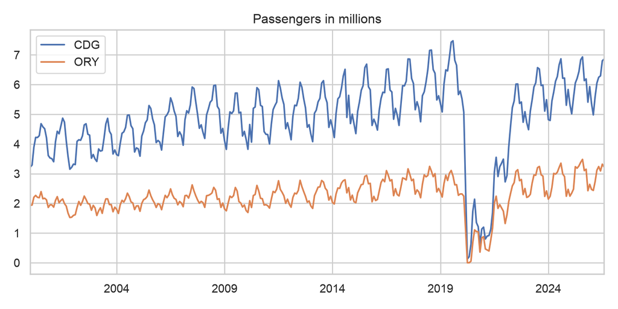

```python
fig, ax = plt.subplots(figsize=(8, 4))
air_data.to_timestamp().div(1e6).plot(ax=ax)
ax.set(title="Passengers in millions", xlabel="", ylabel="")
fig.tight_layout()
plt.show()
```

What are some patterns that we can identify?

Both decomposition examples interpolate missing months and use an additive decomposition with a 12 month seasonal period.

**R**

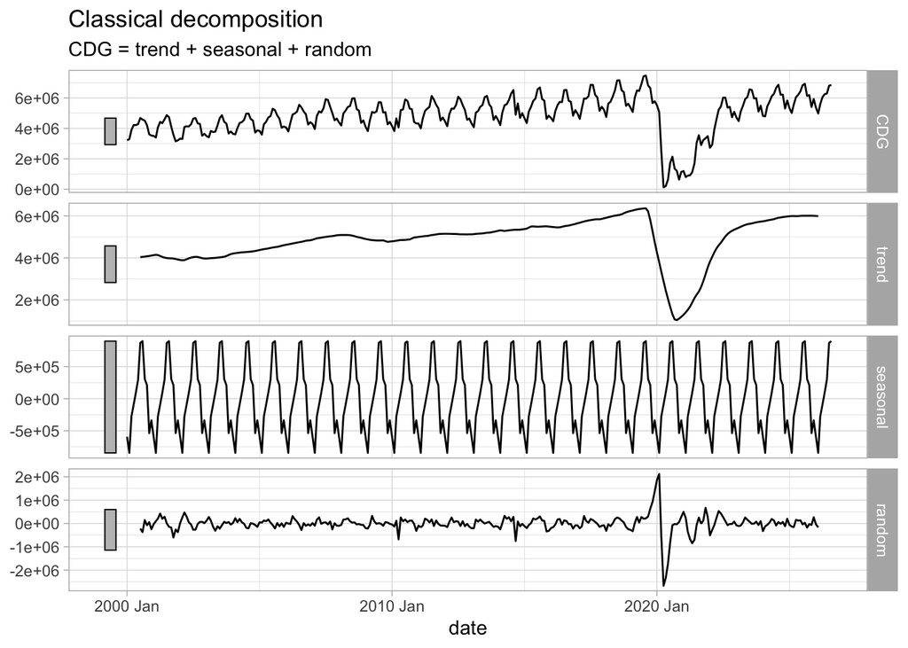

```r
# Interpolate missing months only for decomposition.
air_data %>%
  mutate(CDG = approx(seq_along(CDG), CDG,
                       xout = seq_along(CDG), rule = 2)$y) %>%
  model(classical_decomposition(CDG)) %>%
  components() %>%
  autoplot() + theme_light()
```

**Python**

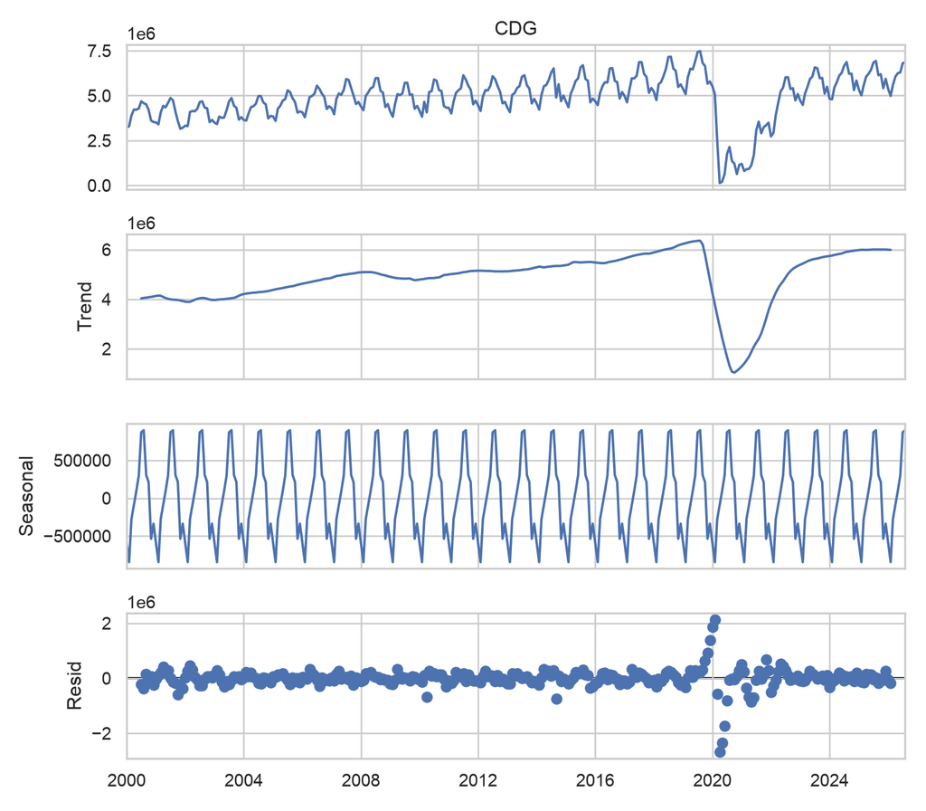

```python
# Interpolate missing months for decomposition; retain the original air_data.
cdg = air_data["CDG"].interpolate(limit_direction="both").to_timestamp()
result = seasonal_decompose(cdg, model="additive", period=12)
fig = result.plot()
fig.set_size_inches(8, 7)
fig.tight_layout()
plt.show()
```

A look at seasonality.

**R**

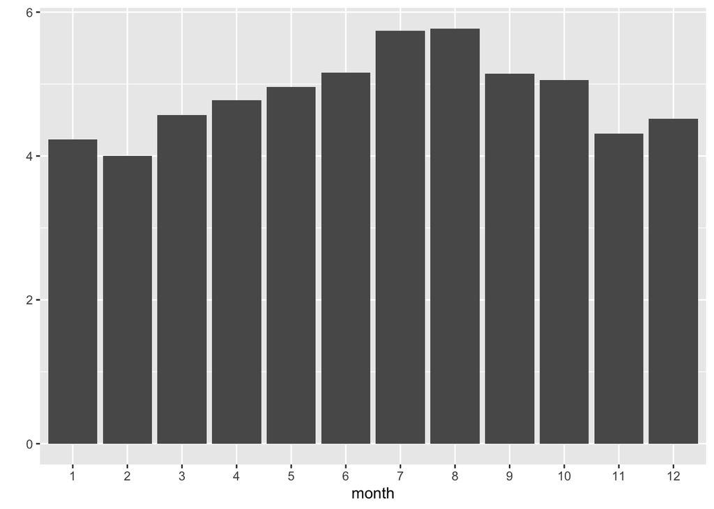

```r
air_data |>
  as.data.frame() |>
  mutate(month = month(date)) |>
  group_by(month) |>
  summarise(avg_pass = mean(CDG/10^6)) |>
  ggplot(aes(x = as.factor(month), y = avg_pass)) + geom_col() +
  xlab("month") + ylab("")
```

**Python**

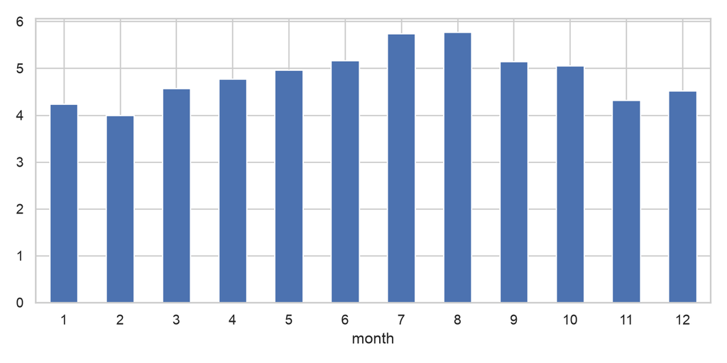

```python
plot_data = (
    air_data.assign(month=air_data.index.month)
    .groupby("month")["CDG"].agg(lambda s: s.mean(skipna=False)) / 1e6
)
fig, ax = plt.subplots(figsize=(8, 4))
plot_data.plot.bar(ax=ax, rot=0)
ax.set(xlabel="month", ylabel="")
fig.tight_layout()
plt.show()
```

Summer months, as expected, have more passenger rotations.

## 4.2 Atmospheric CO2 concentration

Both versions skip NOAA comment lines and treat its missing value marker, `-99.99`, as missing data. Missing monthly concentrations are interpolated only for decomposition.

**R**

```r
url <- "https://gml.noaa.gov/webdata/ccgg/trends/co2/co2_mm_mlo.csv"
co2 <- read.csv(url, comment.char = "#", na.strings = "-99.99")
co2 <- co2 |>
  mutate(date = make_date(year = year, month = month, day = 15)) |>
  select(date, average, deseasonalized) |>
  mutate(date_iso = date,
         date = yearmonth(date)) |>
  as_tsibble(index = date)
```

**Python**

```python
url = "https://gml.noaa.gov/webdata/ccgg/trends/co2/co2_mm_mlo.csv"
response = requests.get(url, timeout=120)
response.raise_for_status()
# NOAA's comment header can change length. Missing observations use -99.99.
co2 = pd.read_csv(io.StringIO(response.text), comment="#", skipinitialspace=True,
                  na_values=[-99.99])
co2["date_iso"] = pd.to_datetime(co2[["year", "month"]].assign(day=15))
co2["date"] = co2["date_iso"].dt.to_period("M")
co2 = co2.set_index("date")[["average", "deseasonalized", "date_iso"]]
co2 = co2.reindex(pd.period_range(co2.index.min(), co2.index.max(), freq="M",
                                  name="date"))
print(co2.head())
```

```
         average  deseasonalized   date_iso
date
1958-03   315.71          314.44 1958-03-15
1958-04   317.45          315.16 1958-04-15
1958-05   317.51          314.69 1958-05-15
1958-06   317.27          315.15 1958-06-15
1958-07   315.87          315.20 1958-07-15
```

A sneak peek…

**R**

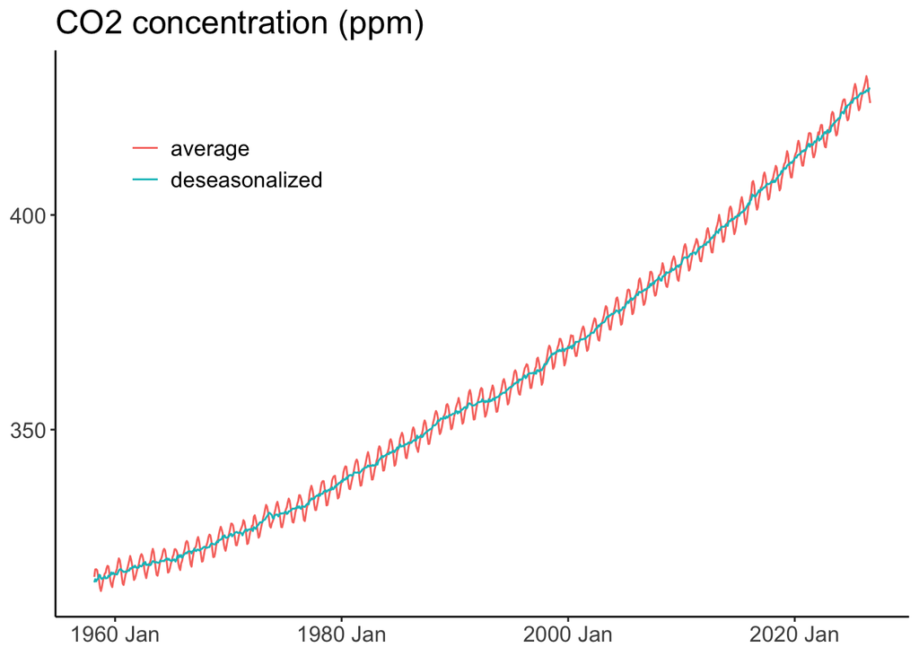

```r
co2 |>
  pivot_longer(-c(date, date_iso), names_to = "series", values_to = "value") |>
  ggplot(aes(x = date, y = value, color = series)) + geom_line() +
  theme_classic() + ggtitle("CO2 concentration (ppm)") +
  theme(legend.position = c(0.2,0.8),
        text = element_text(size = 15),
        legend.title = element_blank(),
        axis.title = element_blank())
```

**Python**

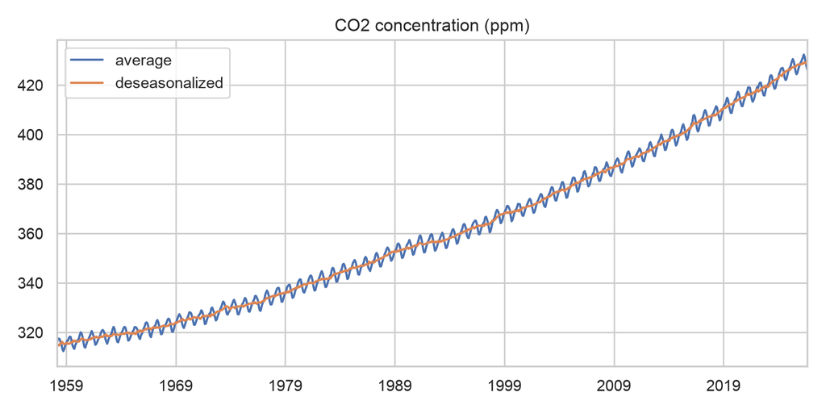

```python
fig, ax = plt.subplots(figsize=(8, 4))
co2[["average", "deseasonalized"]].to_timestamp().plot(ax=ax)
ax.set(title="CO2 concentration (ppm)", xlabel="", ylabel="")
fig.tight_layout()
plt.show()
```

Each dot pairs a CO₂ concentration with global warming for one year, measured relative to the 1850 to 1900 average. The labeled points extend the original figure through 2025.

**R**

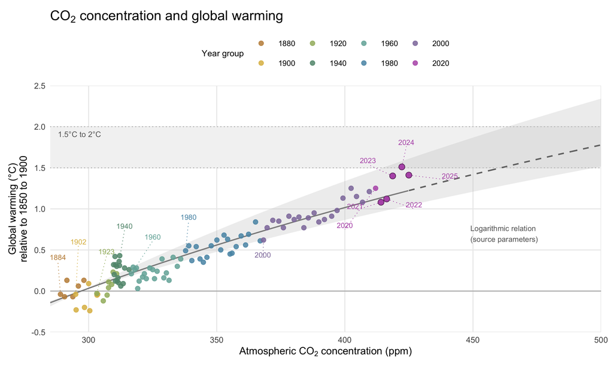

Adapted from [How are CO₂ concentrations related to warming?](https://factsonclimate.org/infographics/concentration-warming-relationship) by [Fakta o klimatu](https://factsonclimate.org), [CC BY 4.0](https://creativecommons.org/licenses/by/4.0/). The 2021–2025 observations use [NASA GISTEMP](https://data.giss.nasa.gov/gistemp/) and [Scripps CO₂](https://scrippsco2.ucsd.edu/data/atmospheric-co2-data/averaged-products/), with the original temperature conversion (+0.2308°C). The gray band retains the source’s model range.

**Python**

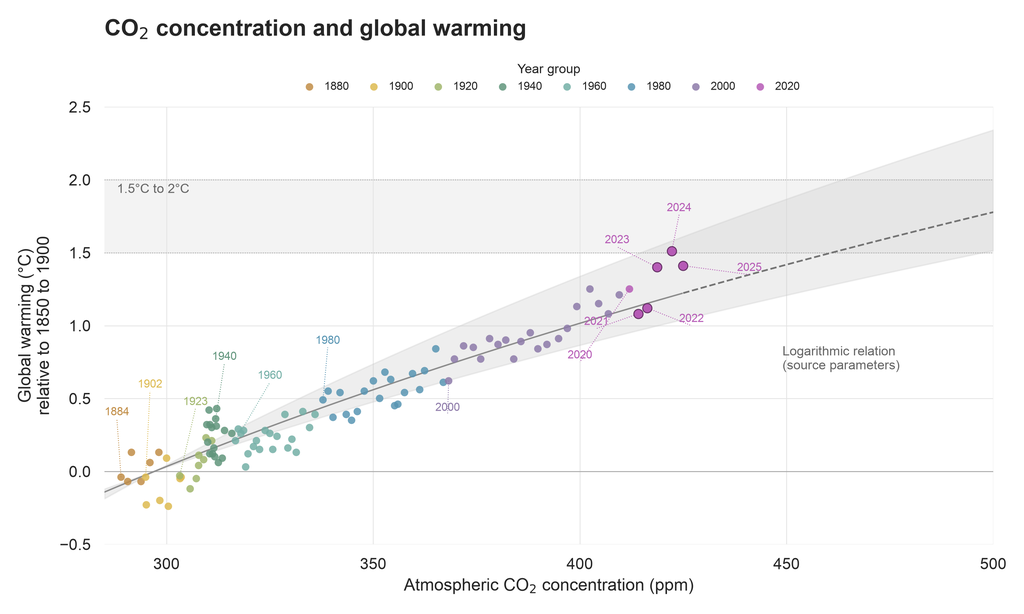

Adapted from [How are CO₂ concentrations related to warming?](https://factsonclimate.org/infographics/concentration-warming-relationship) by [Fakta o klimatu](https://factsonclimate.org), [CC BY 4.0](https://creativecommons.org/licenses/by/4.0/). The 2021–2025 observations use [NASA GISTEMP](https://data.giss.nasa.gov/gistemp/) and [Scripps CO₂](https://scrippsco2.ucsd.edu/data/atmospheric-co2-data/averaged-products/), with the original temperature conversion (+0.2308°C). The gray band retains the source’s model range.

We return to the monthly CO₂ series and decompose its seasonal pattern.

**R**

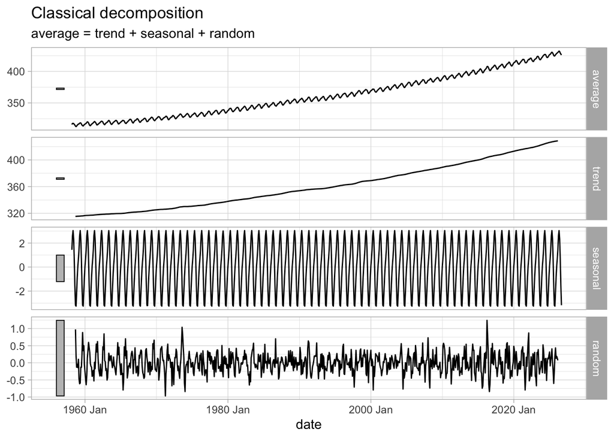

```r
# Interpolate missing months only for decomposition.
co2 %>%
  mutate(average = approx(seq_along(average), average,
                       xout = seq_along(average), rule = 2)$y) %>%
  model(classical_decomposition(average)) %>%
  components() %>%
  autoplot() +
  theme_light()
```

**Python**

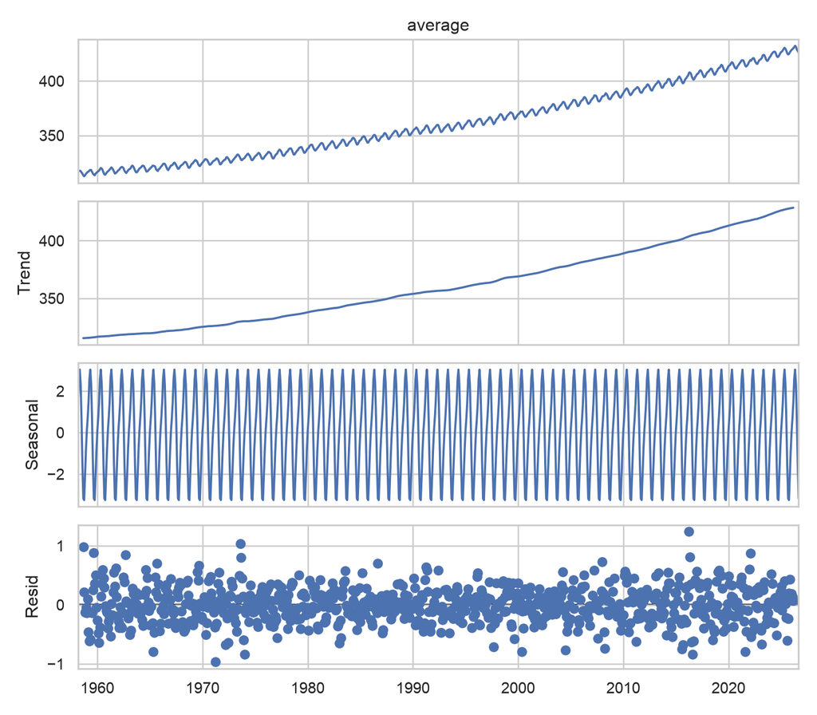

```python
average = co2["average"].interpolate(limit_direction="both").to_timestamp()
result = seasonal_decompose(average, model="additive", period=12)
fig = result.plot()
fig.set_size_inches(8, 7)
fig.tight_layout()
plt.show()
```

## 4.3 Financial series

### 4.3.1 Stocks

**R**

```r
tickers <- c("AAPL", "BA", "C", "PFE", "WMT", "XOM")
# Tickers: Apple, Boeing, Citigroup, Pfizer, Walmart, Exxon
# Others: , "F", "DIS", "GE", "CVX", "MSFT", "GS"
min_date <- "2000-01-01"                      # Starting date
max_date <- "2026-11-03"                      # Ending date
prices <- getSymbols(tickers, src = 'yahoo',  # The data comes from Yahoo Finance
                     from = min_date,         # Start date
                     to = max_date,           # End date
                     auto.assign = TRUE,
                     warnings = FALSE) %>%
  map(~Ad(get(.))) %>%                        # Retrieving the data
  reduce(merge) %>%                           # Merge in one dataframe
  `colnames<-`(tickers)                       # Set the column names
prices |> tail()
```

```
               AAPL     BA        C      PFE    WMT    XOM
2026-10-26 343.6489 188.31 120.3787 29.36130 120.29 184.54
2026-10-27 346.8365 168.18 122.0197 29.37115 119.32 179.91
2026-10-28 343.5689 167.14 123.4320 29.02619 118.77 182.02
2026-10-29 348.6451 172.65 125.0730 29.51899 121.25 183.29
2026-10-30 344.3683 171.55 121.9700 30.08079 123.51 187.25
2026-11-02 338.0631 175.40 123.1000 30.22863 127.69 179.67
```

**Python**

```python
tickers = ["AAPL", "BA", "C", "PFE", "WMT", "XOM"]
min_date = "2000-01-01"
max_date = "2026-11-03"
# Explicitly request adjusted closes, matching quantmod::Ad().
stock_quotes = yf.download(tickers, start=min_date, end=max_date,
                           auto_adjust=False, progress=False)
prices = stock_quotes["Adj Close"].reindex(columns=tickers)
if prices.empty or prices.isna().all().any():
    raise ValueError("Yahoo Finance returned no prices for one or more stocks.")
print(prices.tail())
```

```
Ticker            AAPL          BA           C        PFE         WMT  \
Date
2026-10-27  346.836487  168.179993  122.019730  29.371151  119.320000
2026-10-28  343.568939  167.139999  123.431969  29.026190  118.769997
2026-10-29  348.645111  172.649994  125.072960  29.518993  121.250000
2026-10-30  344.368347  171.550003  121.970001  30.080791  123.510002
2026-11-02  338.063141  175.399994  123.099998  30.228632  127.690002

Ticker             XOM
Date
2026-10-27  179.910004
2026-10-28  182.020004
2026-10-29  183.289993
2026-10-30  187.250000
2026-11-02  179.669998
```

**R**

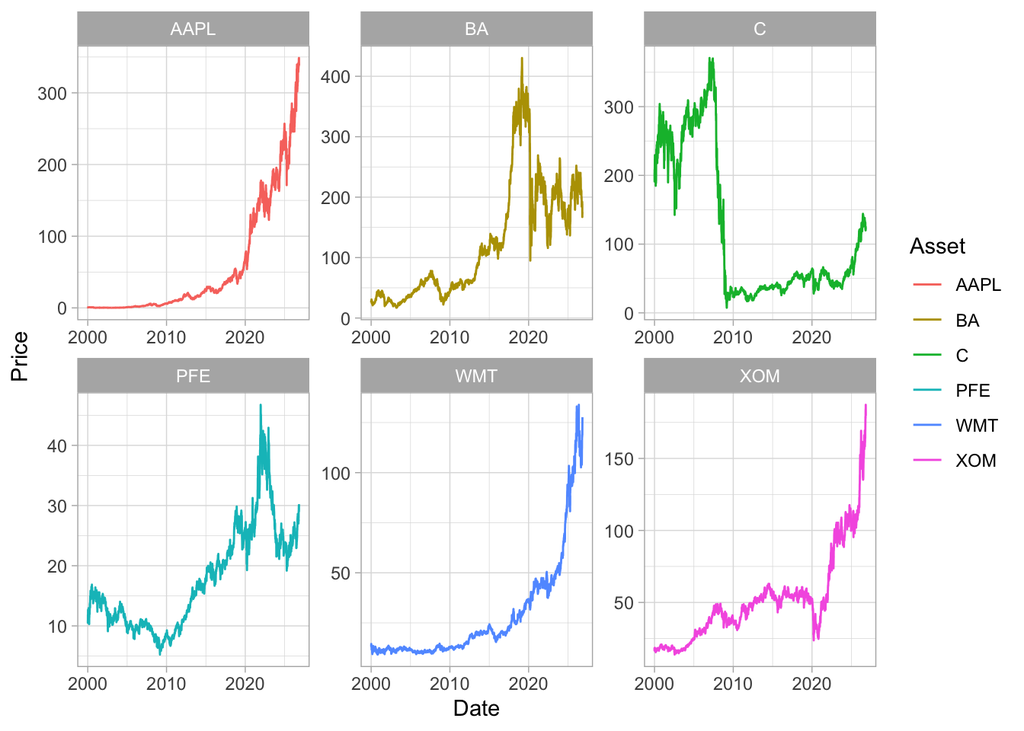

```r
prices %>%
  as.data.frame() %>%
  rownames_to_column(var = "Date") %>%
  mutate(Date = as.Date(Date)) |>
  pivot_longer(-Date, names_to = "Asset",
               values_to = "Price") %>%
  ggplot(aes(x = Date, y = Price, color = Asset)) + geom_line() +
  facet_wrap(vars(Asset), scales = "free") + theme_light()
```

**Python**

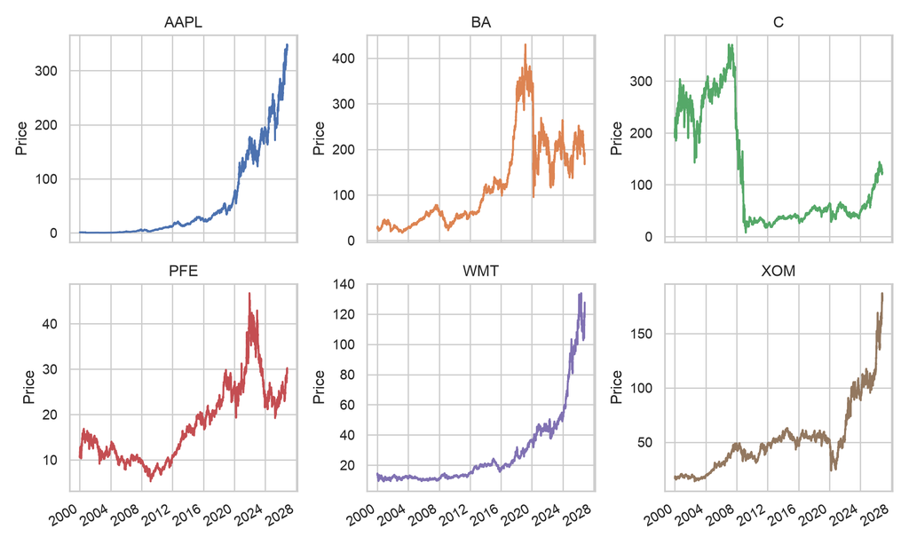

```python
axes = prices.plot(subplots=True, layout=(2, 3), figsize=(10, 6),
                   sharey=False, legend=False)
for ax, ticker in zip(axes.flat, tickers):
    ax.set(title=ticker, xlabel="", ylabel="Price")
plt.tight_layout()
plt.show()
```

Any **pattern** that you can recognize?

### 4.3.2 Cryptocurrencies

The R examples retain `crypto2`, which retrieves CoinMarketCap data. The Python examples use [CoinGecko](https://docs.coingecko.com/reference/coins-list) for the coin directory and market information. They use [yfinance](https://ranaroussi.github.io/yfinance/reference/api/yfinance.download.html) for historical USD closing prices. CoinGecko identifiers differ from CoinMarketCap slugs; XRP uses `ripple` on CoinGecko and `XRP-USD` on Yahoo Finance. Provider coverage, coin ordering, and prices can differ, so these outputs illustrate equivalent operations rather than identical datasets. These online services can impose rate limits or change their access requirements.

We will use the `{crypto2}` package below. If need be: install it.  
First, let’s have a look at the list of available coins… which are numerous!

**R**

```r
coins <- crypto_list()
```

**Python**

```python
# CoinGecko supplies the coin directory; the R tab uses CoinMarketCap.
response = requests.get("https://api.coingecko.com/api/v3/coins/list", timeout=120)
response.raise_for_status()
coins = pd.DataFrame(response.json())
print(coins.head())
```

```
                                       id                            symbol  \
0                                       _                               gib
1                             000-capital                               000
2  01111010011110000110001001110100-token  01111010011110000110001001110100
3  01112131415161718192021222324252-token                        1234567891
4                                01-token                                01

                               name
0                        ༼ つ ◕_◕ ༽つ
1                       000 Capital
2  01111010011110000110001001110100
3  01112131415161718192021222324252
4                                01
```

You can have a look at the info for the coins via the code below.

**R**

```r
c_info <- crypto_info(coin_list = coins, limit = 30)
```

```
❯ Scraping crypto info
```

```
❯ Processing crypto info
```

**Python**

```python
# Market information for the top 30 coins by market capitalization.
response = requests.get(
    "https://api.coingecko.com/api/v3/coins/markets",
    params={"vs_currency": "usd", "order": "market_cap_desc",
            "per_page": 30, "page": 1},
    timeout=120,
)
response.raise_for_status()
c_info = pd.DataFrame(response.json())
print(c_info[["id", "symbol", "name", "current_price", "market_cap"]].head())
```

```
            id symbol      name  current_price     market_cap
0      bitcoin    btc   Bitcoin   65899.000000  1325348919539
1     ethereum    eth  Ethereum    1846.730000   225704419874
2       tether   usdt    Tether       0.999467   175304529608
3  binancecoin    bnb       BNB     592.110000    77869318590
4     usd-coin   usdc      USDC       0.999697    69053410746
```

Next, we can download **historical quotes**.  
Symbols can have duplicates, so R uses CoinMarketCap slugs and Python uses explicit Yahoo Finance tickers.

**R**

```r
coin_symb <- c("bitcoin", "ethereum", "tether", "xrp")
coin_hist <- crypto_history(coins |> dplyr::filter(slug %in% coin_symb),
                            start_date = "20170101",
                            end_date = "20261103")
```

```
❯ Scraping historical crypto data
```

```
❯ Processing historical crypto data
```

**Python**

```python
# Yahoo Finance supplies daily USD closes; provider coverage can differ from R.
coin_tickers = {"BTC-USD": "bitcoin", "ETH-USD": "ethereum",
                "USDT-USD": "tether", "XRP-USD": "xrp"}
crypto_quotes = yf.download(list(coin_tickers), start="2017-01-01",
                            end="2026-11-04", auto_adjust=False, progress=False)
closes = crypto_quotes["Close"].reindex(columns=list(coin_tickers))
if closes.empty or closes.isna().all().any():
    raise ValueError("Yahoo Finance returned no prices for one or more coins.")
closes.index.name = "date"
coin_hist = (
    closes.rename(columns=coin_tickers).reset_index()
    .melt(id_vars="date", var_name="name", value_name="close")
    .dropna(subset=["close"])
)
coin_hist["timestamp"] = pd.to_datetime(coin_hist.pop("date"), utc=True).map(
    lambda date: int(date.timestamp())
)
print(coin_hist.head())
```

```
      name        close   timestamp
0  bitcoin   998.325012  1483228800
1  bitcoin  1021.750000  1483315200
2  bitcoin  1043.839966  1483401600
3  bitcoin  1154.729980  1483488000
4  bitcoin  1013.380005  1483574400
```

**R**

```r
coin_hist <- coin_hist |>  # Timestamps are at midnight.
  mutate(date = as.Date(as.POSIXct(timestamp, origin="1970-01-01")))
```

**Python**

```python
coin_hist["date"] = pd.to_datetime(coin_hist["timestamp"], unit="s", utc=True)
print(coin_hist.head())
```

```
      name        close   timestamp                      date
0  bitcoin   998.325012  1483228800 2017-01-01 00:00:00+00:00
1  bitcoin  1021.750000  1483315200 2017-01-02 00:00:00+00:00
2  bitcoin  1043.839966  1483401600 2017-01-03 00:00:00+00:00
3  bitcoin  1154.729980  1483488000 2017-01-04 00:00:00+00:00
4  bitcoin  1013.380005  1483574400 2017-01-05 00:00:00+00:00
```

Mind the log-scale!

**R**

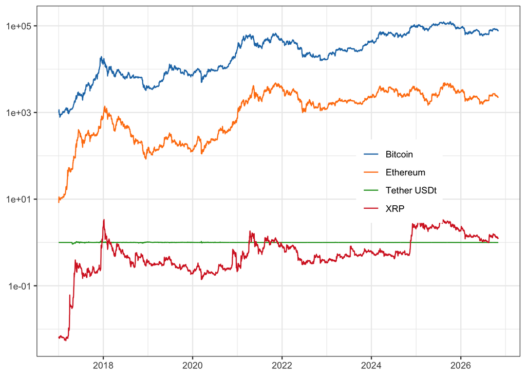

```r
coin_hist |>
  ggplot(aes(x = date, y = close, color = name)) + geom_line() +
  scale_y_log10() + theme_bw() + scale_color_d3() +
  theme(legend.position = c(0.75,0.5),
        axis.title = element_blank(),
        legend.title = element_blank())
```

**Python**

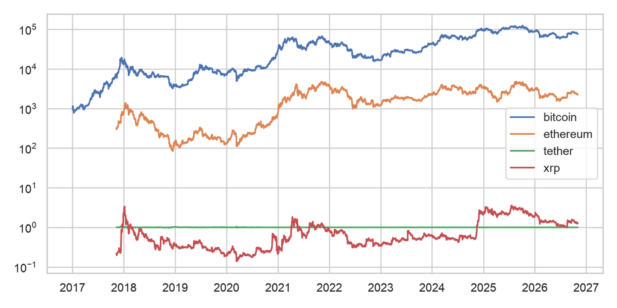

```python
fig, ax = plt.subplots(figsize=(8, 4))
sns.lineplot(data=coin_hist, x="date", y="close", hue="name", ax=ax)
ax.set(yscale="log", xlabel="", ylabel="")
ax.legend(title="")
fig.tight_layout()
plt.show()
```

Any **pattern** that you can recognize here again?

Unfortunately, this kind of data is hard to analyze directly - more on that next time!

# 5 Descriptive statistics (to be done in class)

Pick a dataset… & explore!

1. What is the average rate of increase of CO$_2$ in the atmosphere?
2. Using the code below, determine during which month airports see the most passengers.
3. Which stock/crypto had the best performance over the sample we downloaded?
4. Which country is the richest (GDP per capita), and which one spends the most on R&D, or education?

**R**

```r
air_data |> mutate(month = month(date))
```

**Python**

```python
# Add a month column before grouping to explore the exercise.
air_data.assign(month=air_data.index.month)
```

# 6 Wrap-up

The things you need to remember:

- Python uses pandas operations such as `query`, column selection, `sort_values`, `assign`, `groupby`, and `agg`.
- The **tidyverse** functions: filter, select, arrange, mutate, group_by and summarize. They are incredible tools to analyze data rapidly.
- There are a small number of patterns that are easy to recognize (seasonality, trends). But there are also unpredictable shocks, some small, some very large. It is these shocks that we will try to model henceforth.